# probability distrubtion and stats

probability distribution let we have a data 10000 customers - Age(min=12, max=96) 0% = 12 5% = 14 10% = 18 20% = 22 25% = 24.6 50% = 36 75% = 58 90% = 66 95% = 72 99% = 88 100 = 96 p(age<66) : 90% p(age>72) : 100% - p(age<72)=100-95 = 5% p(age>22 and age<66) = 70% what if the p(age>25) p(age>30 and age<60) bins freq ------ ------ 12-14 (smaller intervel binning) let 5 14-16 3 16-18 8 18-20 9 20-22 11 .. .. .. 92-94 2 94-96 1 we draw a bar graph binning intervwls in x axis and frequency in y axis we draw a curve which roughly connects all points This is how Histagram is generated we get f(x) curve the integration of the f(x) will give us area under the curve ----------------------------------------------------------------------- f(x) :probability Distribution funcion -There are ~20 commonly occuring probability functions -Almost 99% of the data follows either one of those 20 This is an emerical rule we have those f(x) for the PDcurves, so we can apply that to the suitable data we have also defined standard scales and corresponding probability % whatever is the data points and its distribution , we can convert data into its standard form E.g., If age follows exponential curve can be converted to standard exp curve ------------------------------------------------------------------------- Normal Distrubtion -displot gives bell curve let say we have data points whose size is > 30 Tendence ~68% of the data lies between mean +/- sd LC = mean -sd UC = mean +sd data[data > LC | data < UC] mean+/- sd : 68% mean+/- 2*sd : 95% mean+/- 3*sd : 99.7% - curve is perfectly symmtric - skew close to zero - kurtosis : -2 to +2 - mean==median==mode - Hypothesis testing to prove normality - Shapiro wilk's Test - Anderson-Darling Test -Any distribution can be converted to normal distribution using suitable transformation Standard normal distrubtions - a normal distribution so converted that its new mean =0 sd=1 -this transformation : Z transform Z_value = x_value - mean --------------- std if age follows a normal distrubtion p(weight>141) 1-p(weight<141) p(weight<141) = 141 - 109 --------- = 2.46 =0.99266% 13 p(weight>141) =0.00744 p(weight<120) = 120-109 ------- = 0.8461 =79.955% 13

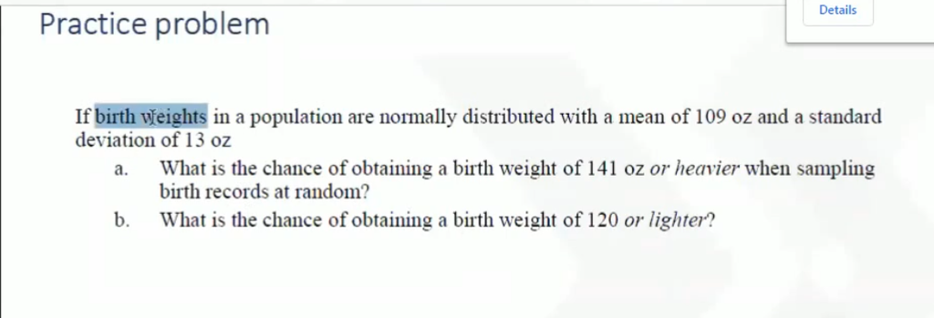

p(weight>141) 1-p(weight<141) p(weight<141) = 141 - 109 --------- = 2.46 =0.99266% 13 p(weight>141) =0.00744 p(weight<120) = 120-109 ------- = 0.8461 =79.955%Central Limit Theorm ----------------------- A data follows any distribution , if we take enough samples E.g. whats the price of i kg of rice in Maxico Sample1 : 5 variants of rice : mean_s1 Sample2 : 10 variants of rice : mean_s2 Sample3 : 1 variants of rice : mean_s3 ... ... s50: :mean_s50 ------------ mean(all samples) 1. the mean of all samples follow normal distribution 2. the mean of all sample means is equal to population Mean 3. the SD of samples mean is error factor = Standard error Standard error = SD(population)/sqrt(sample_size) z-Test and T-test- -z-test is a test to prove if a sample mean is significantely different from population mean or not - It is applicable if data is normally distributed - sample size is atleast 30 - we know the population mean and std div Student 's t test is a test to prove if a sample mean is significantely different from population mean or not - It is applicable if data is not normally distributed- t distribution - sample size is < 30 - we dont know the population mean and std div when to use : - to compare a sample estimation with a population - to compare 2 estimators from a sample E.g. score_test1 vs score_test2 jan_spend vs mar_spend for 200 customers -python -ttest - one sample t test -two sample t test - independ sample t test E.g jan_spend(male) vs jan_spend(female)

[figure not shown]

## Hypothesis Testing

-Step1 : Define the null and alt hypothesis Null/H)/Ho : mostly checks equality Alt/H1/Ha : mostly checks for different/ inequality check for > check for < -Step2 : see which stats method can we apply? Z-Test T test F test X2 test

-step3 : what is the test statistics and p value? and level of confidence Z-Test T test F test X2 test

-Step4 : what to do with the Null Hypothesis based on the above values??

```
     - do we reject null hypothesis
     - Do we fail to reject the null hypothesisn (accept)

   If p is high we fail to reject the null
   If p is loww we reject the null
```

-step 5 : Conclusion

Ans: 1 H0: pop mean is exactly 92(u=92) Ha: pop mean is not equal to 92,its different u!=92

2 - Normally dis ?? Yes

```
 - Do we have pop info?? yes
 - is the same size> 30? yes
 - So which test? Z test
```

## 3. Test Stastics? Z Score = sample mean-pop_mean

```
                         SD/sqrt(n)

                         93.6-92
                         --------       = 3.65
                         3.1/sqrt(50)
        for the decided CI of 95% the upper and lower cutoff
        UC=mean+1.96*SE
        LC=mean-1.96*SE
```

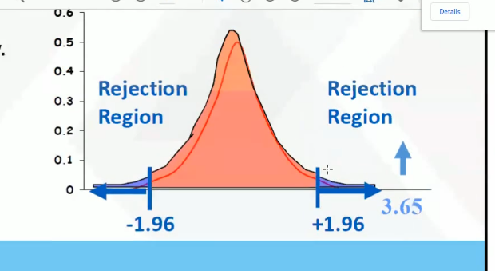

conclusion : we reject the Null Hypothesis

```
         The petrol price in melbourn is diff from 92
```

```python
import numpy as np
import pandas as pd
import seaborn as sns
from matplotlib import pyplot as plt
```

[output not shown]

[output cut: 22 more lines]

[output not shown]

[output not shown]

[output not shown]

[output cut: 18 more lines]

[output not shown]

[output not shown]

```python
data=pd.Series(np.random.normal(loc=110 ,scale = 10, size=10000))
# loc means central tendncy
# scale means std deviation
```

```python
data
```

```
0       106.815679
1       112.765677
2       102.912704
3       122.161152
4       113.942089
           ...
9995    100.888295
9996    117.934763
9997    106.499901
9998    109.883819
9999    107.993178
Length: 10000, dtype: float64
```

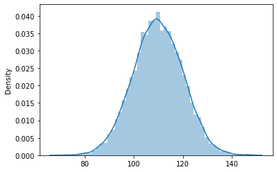

```python
sns.distplot(data)
plt.show()
```

```python
data.mean()
```

```
np.float64(109.81953872823456)
```

```python
data.std()
```

```
np.float64(10.098677297465043)
```

```python
LC=data.mean()-data.std()
UC=data.mean()+data.std()
```

```python
len(data[(data>LC)&(data<UC)])/len(data)*100
```

```
68.05
```

```python
LC=data.mean()-2*data.std()
UC=data.mean()+2*data.std()
len(data[(data>LC)&(data<UC)])/len(data)*100
```

```
95.65
```

```python
LC=data.mean()-3*data.std()
UC=data.mean()+3*data.std()
len(data[(data>LC)&(data<UC)])/len(data)*100
```

```
99.72999999999999
```

```python
data.skew()
```

```
np.float64(-0.009189262514076894)
```

```python
data.kurtosis()
```

```
np.float64(-0.002579663020549905)
```

```python
data.median()
```

```
np.float64(109.79850151241288)
```

```python
#Standard Gaussian/Normal
z_data = (data-data.mean())/data.std()
```

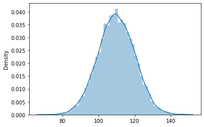

```python
sns.distplot(data)

plt.show()
```

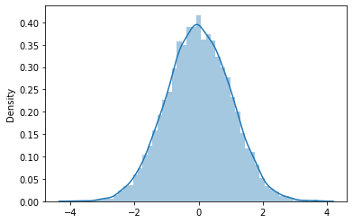

```python
sns.distplot(z_data)
plt.show()
```

```python
z_data.mean()
```

```
np.float64(-2.3110402480597257e-16)
```

```python
z_data.std()
```

```
np.float64(1.0)
```

```python
data2=pd.Series(np.random.randint(40,high=100,size=1000,dtype=int))
```

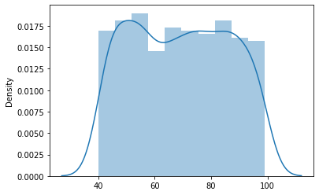

```python
sns.distplot(data2)
```

```python
s1_mean = data2.sample(n=10).mean()
```

```python
all_sample_means=[]
for i in range(0,150):
    all_sample_means.append(data2.sample(n=10).mean())
all_sample_means = pd.Series(all_sample_means)
len(all_sample_means)
```

```
150
```

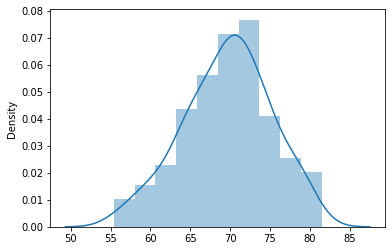

```python
sns.distplot(all_sample_means)
```

```python
data2.mean()
```

```
np.float64(69.037)
```

```python
all_sample_means.mean()
```

```
np.float64(69.64266666666666)
```

```python
data2.mean()-all_sample_means.mean()
```

```
np.float64(-0.6056666666666501)
```

```python
data2.std()/np.sqrt(150)
```

```
np.float64(1.4102196966878102)
```